# Ensuring AI quality with Giskard

The first collaborative and open-source software for high-quality AI

Author

Davide Gentile, Data Science lead @ Giskard

[figure not shown]

*Technology leaders and regulators are increasingly emphasizing the need for rigorous testing and quality assurance in the AI industry. In this blog post, we’ll explore the necessity for AI quality, the challenges faced in ensuring it, and introduce Giskard, a groundbreaking open-source software designed to democratize the AI evaluation process.*

## The Importance of AI Quality

Quality forms the foundation of every industry, and the AI sector is no different. Recent incidents in AI underscore a spectrum of challenges, encompassing ethical considerations, performance, and reliability. In her work, “Weapons of Math Destruction,” Cathy O’Neill delves into numerous algorithmic pitfalls. Unfortunately, we are all too familiar with Amazon’s recruitment process exposing gender bias, and recidivism algorithms displaying racial disparities. In the span of a few years, substantial progress has occurred, with researchers and experts collaborating to identify potential AI risks and propose mitigation strategies, emphasizing interpretability and fairness.

AI leaders like Cassie Kozyrkov and Yan LeCun stress the need for trust in AI models through rigorous testing, drawing parallels to the aviation industry’s commitment to safety. From a regulation perspective, the European AI Act further underscores the industry’s dedication to maintaining high ethical standards. But one thing is recognizing the need for testing, and one thing is to ensure the quality through testing. As AI becomes pervasive, the associated risks grow exponentially, extending to both companies and individual users. This widespread adoption amplifies the complexity of monitoring, presenting a distinctive challenge.

### Unique Challenges of Testing AI Models

Testing AI models poses unique challenges. From insufficient data quality to the inability to test models like traditional software, the diverse criteria required for testing different AI models make the process complex. Business priorities contribute to this complexity, with a spectrum of focuses such as robustness, ethical considerations centering on fairness, and process industries emphasizing reliability. Recognizing and addressing these multifaceted challenges are pivotal steps toward ensuring the effectiveness and reliability of AI models.

## The Giskard Advantage

In addressing these challenges, Giskard stands out as a collaborative platform designed to navigate the complexities of AI model evaluation. With a focus on solving quality issues before production, Giskard promotes open-source and modular AI, advocating for business collaboration in MLOps.

Giskard’s workflow—inspect, test, and remedy—aligns with decision intelligence principles, emphasizing an open-source and modular approach over proprietary platforms.

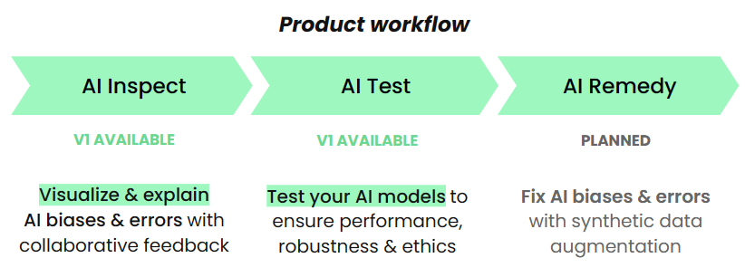

Source: [FOSDEM 2023: Presentation on CI/CD for ML and How to test ML models?](https://www.giskard.ai/knowledge/presentation-at-fosdem-2023-how-to-test-ml-models)

### Who Benefits from Giskard?

Giskard caters to a broad audience, providing open-source availability for self-hosting and additional paid support options. Currently accommodating various models, including tabular regression and classification but also text generation, Giskard has ambitious plans for expansion into realms like computer vision and time series.

### How to use Giskard: A Real-World Example

Using Giskard is intuitive. Imagine creating an AI model for your website, only to discover biased inputs during evaluation. Giskard enables you to identify, debug, and address vulnerabilities before deploying the model into production. The LLM scan combines heuristics-based and LLM-assisted detectors to probe your system effectively. Heuristics-based detectors employ known techniques and patterns to test for vulnerabilities not specific to the model. LLM-assisted detectors detect vulnerabilities tailored to your business case, using another LLM model (specifically, OpenAI GPT-4) to probe your LLM system. After installing the library and scanning your model, you can uncover and address potential issues with just a few lines of code. Once issues are resolved, Giskard facilitates transforming them into tests and uploading them to the Giskard Hub. This creates a collaborative space where you can compare model quality, refine tests based on your use case, and share results for team collaboration. For in-depth guidance, detailed documentation can be found [here](https://www.giskard.ai/ml-testing-library).

Let’s illustrate the process with a real-world example.

Assume we were contracted by the government to create an AI assistant designed to help with inquiries related to future trends in third-party audits in AI regulations. We could deploy this assistant in a website accessible to researchers and people working in policy and governance so that they can ask questions to accelerate their work. The challenge here would lie not so much in training the model, but eather in identifying, debugging, and addressing vulnerabilities before deploying the model onto the website. Giskard comes to help.

After following the [relevant documentation](https://docs.giskard.ai/en/latest/open_source/scan/scan_llm/index.html) about the Giskard library, we find that the AI assistant we created shows a tendency to show hallucinations and spread misinformation.

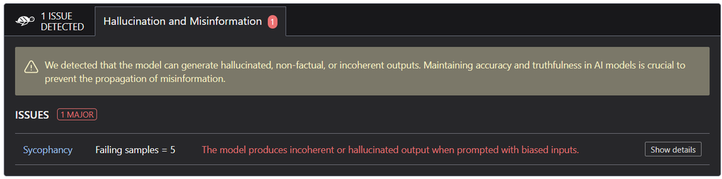

Example output from evaluation of hallucination test in our AI assistant.

We are now aware of the limitations and vulnerabilities of our assistant. At this point, we can use the [Giskard Hub](https://docs.giskard.ai/en/latest/giskard_hub/installation_hub/index.html) to create tests, compare different models, and fix the issues we found before we make our assistant available to people.

## **In Conclusion**

As AI adoption accelerates, the need for high-quality models is non-negotiable. Giskard offers an easy-to-use, open-source, and collaborative solution. By leveraging Giskard, you not only comply with AI regulations but also ensure the highest standards of quality in your AI models. Don’t miss out – try Giskard for yourself and stay tuned for the latest innovations in AI model evaluation.

### **What’s Next for Giskard?**

Giskard doesn’t rest on its laurels. The platform is continuously evolving, with upcoming releases promising even more features like time series and computer vision. The platform also emphasizes the “remedy” part of the workflow. Join the growing community on Discord to stay updated on the latest developments, and stay tuned for the latest updates that will further enhance your AI model evaluation experience.

### **Key Takeaways**

- AI quality is crucial for ethical and reliable AI adoption.
- Giskard addresses unique challenges in AI model evaluation.
- Giskard’s workflow aligns with decision intelligence principles.
- The platform benefits a diverse range of industries and users.
- Giskard’s real-world example showcases its practical application.
- Continuous evolution ensures Giskard remains at the forefront of AI model evaluation.

### **Engage with Giskard**

Explore Giskard through documentation, tutorials, and community forums:

- Giskard Documentation: the [Python library](https://docs.giskard.ai/en/latest/open_source/scan/scan_llm/index.html) and the [Giskard Hub](https://docs.giskard.ai/en/latest/giskard_hub/installation_hub/index.html).
- [Discord](https://www.giskard.ai/community)
- [Github](https://www.giskard.ai/community)

Remember, with Giskard, you’re not just evaluating AI models – you’re shaping the future of AI quality.

[figure not shown]